# Exam 1

## Exam 1

#### Question

1. El líder de un programa de adopción de mascotas encuestó a 150 personas para conocer qué animal les interesaría adoptar. Del total de encuestados, el 45% adoptaría un erizo, el 35% adoptaría un pez y el 20% adoptaría una cabra.

   ¿Cuál de las siguientes representaciones muestra correctamente la información recolectada en la encuesta?

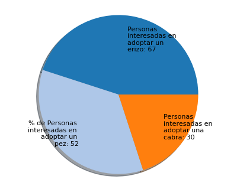

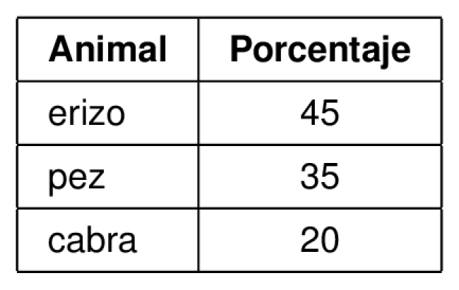

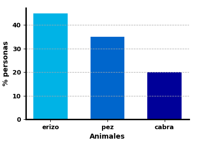

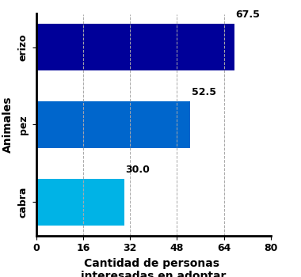

#### Solution

   La gráfica que representa correctamente la información recolectada en la encuesta es el **gráfico de barras horizontales**.

   **Análisis de las representaciones:**
   - **Tabla**: Incorrecto. Aunque muestra los porcentajes correctos, no permite visualizar de manera intuitiva las diferencias entre las cantidades de personas interesadas en cada animal.
   - **Gráfico de barras verticales**: Incorrecto. Aunque muestra correctamente los porcentajes, este formato no permite identificar fácilmente las cantidades absolutas de personas interesadas en cada animal, información que es más útil para la toma de decisiones del programa de adopción.
   - **Gráfico de barras horizontales**: **Correcto**. Este gráfico muestra correctamente las cantidades absolutas de personas interesadas en adoptar cada animal, proporcionando una representación visual clara y precisa de los datos recolectados en la encuesta.
   - **Gráfico de torta**: Incorrecto. Aunque muestra las cantidades absolutas, presenta inconsistencias en las etiquetas (mezcla “Personas interesadas” con “% de Personas interesadas”) y el formato circular dificulta la comparación precisa entre las cantidades.

   **Gráfico correcto:**

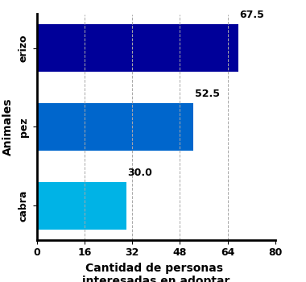